title: “Oefeningen hoofdstuk 3 - analyse op 1 variabele” author: “Tijs Martens” date: “6 maart 2019” output: pdf_document: default html_document: df_print: paged —

# oefening 3.1.

*(oefening zelf gemaakt, geen oplossing)*

## opgave

wat is de gemiddelde lengte van de superhelden

lengtes van de helden:

- x1 = 141
- x2 = 198
- x3 = 143
- x4 = 201
- x5 = 184

## oplossing

*zie cursus blad 1*

oplossing is 173.4

# oefening 3.2.

## opgave

Het gemiddelde van 15 cijfers is 12. Welk nummer moeten we aan de rij van cijfers toevoegen om een gemiddelde van 13 te bekomen?

## oplossing

*zie cursus blad 1*

oplossing is 28

# oefening 3.3.

## opgave

Met welke voorgaande statistiek komt Q2 overeen

## oplossing

Mediaan

Als de mediaan een lijst in 2 delen splitst kan de mediaan van de eerste lijst gezien worden als Q1

Als de mediaan een lijst in 2 delen splitst kan de mediaan van de tweede lijst gezien worden als Q3

# oefening 3.4.

*(oefening zelf gemaakt, geen oplossing)*

## opgave

De formules voor gemiddelde $\mu$ en variantie $\sigma^2$ staan beschreven in secties 3.2 en 3.7, resp. Hoe moeten deze formules aangepast worden om $\mu$ en $\sigma^2$ te berekenen wanneer we te maken hebben met een frequentietabel? Doe dit voor de data in tabel 3.3.

## oplossing

orginele formules:

$\mu = 1(/2) * \sum_i^n x_i$

$\sigma^2$ = de som van alle verschillen met het gemiddelde gedeeld door het aantal voorkomens

*zie cursus blad 2*

**oplossing chamilo:**

de mogelijke scores

```r
x <- 0:10
x
```

```
##  [1]  0  1  2  3  4  5  6  7  8  9 10
```

het aantal voorkomens van elke score:

```r
f_x <- c(2,1,2,0,2,4,9,11,13,8,8)
f_x
```

```
##  [1]  2  1  2  0  2  4  9 11 13  8  8
```

gemiddelde:

```r
m <- sum(x*f_x)/sum(f_x)
m
```

```
## [1] 7
```

```r
v <- sum(f_x * (x - m) ^ 2) / sum(f_x)
v
```

```
## [1] 5.733333
```

standaardafwijking:

```r
stdev <- sqrt(v)
stdev
```

```
## [1] 2.394438
```

# oefening 3.5

## we gaan na als volgende formules een goed alternatief zijn voor die van de variantie

- $\sum_i^n(x_i - \mu)$
- $\sum_i^n \mid (x_i - \mu) \mid$
- $\sum_i^n (x_i - \mu)^2$

### allocatie van de sets

```r
x <- c(4,4,-4,-4)
y <- c(7,1,-6,-2)
```

### formule 1

```r
meanX <- mean(x)
meanY <- mean(y)
var_1x <- x - meanX
var_1y <- y - meanY
var_1x
```

```
## [1]  4  4 -4 -4
```

```r
var_1y
```

```
## [1]  7  1 -6 -2
```

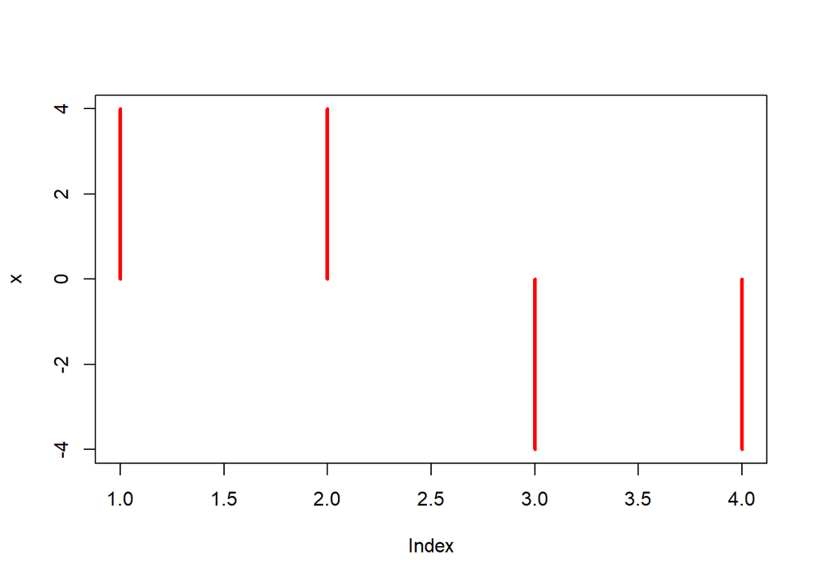

```r
som_1x <- 1/length(x) * sum(var_1x)
som_1y <- 1/length(y) * sum(var_1y)
plot(x,type="h", col='red', lwd=3)
```

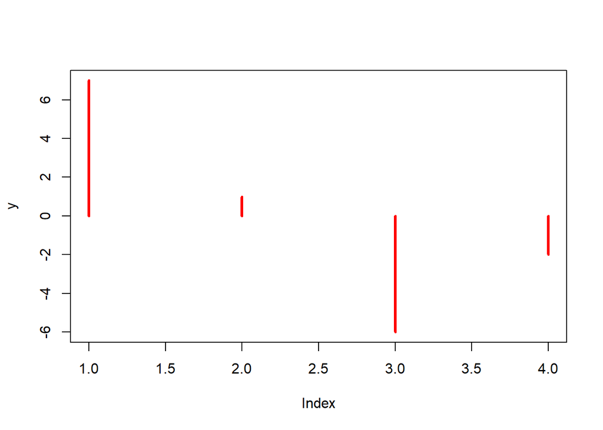

```r
plot(y,type="h", col='red', lwd=3)
```

### formule 2

```r
var_2x <- abs(x - meanX)
var_2x
```

```
## [1] 4 4 4 4
```

```r
var_2y <- abs(y - meanY)
var_2y
```

```
## [1] 7 1 6 2
```

```r
sum_2x <- 1/length(x) * sum(var_2x)
sum_2y <- 1/length(y) * sum(var_2y)
sum_2x
```

```
## [1] 4
```

```r
sum_2y
```

```
## [1] 4
```

#### conclusie

Het probleem hierbij dat we voor beide datasets, hoewel dzez duidelijk visueel een verschillende spreiding hebben, dezelfde waarde bepaald wordt. Blijkbaar worden kleine waarden evenwaardig beschouwd als grote waarden (deviaties). Dit wordt natuurlijk opgelost door kwadraat te nemen

### formule 3

```r
var_3x <- var(x)
var_3y <- var(y)
var_3x
```

```
## [1] 21.33333
```

```r
var_3y
```

```
## [1] 30
```

# oefening 3.6.

*(oefening zelf gemaakt, geen oplossing)*

## opgave

Zoek eens zelfstandig op wat de variatiecoëfficient is, Hoe wordt die gedefinieed voor een volledige populatie en wat zou je ermee kunnen doen.

## oplossing

*wat*: Het is een relatieve spreidingsmaat. De spreiding wordt gemeten ten opzichte van het gemiddelde.

*variatiecoëfficient voor de populatie*: $C_v = \frac{\sigma}{|\mu|}$

*variatiecoëfficient voor de populatie* $C_v = \frac{\sigma}{\bar{a}}$

De variatiecoëfficient kan gebruikt worden om eenvoudig standaardafijkingen van datasets met elkaar te vergelijken.

# oefening 3.7.

*(oefening zelf gemaakt, geen oplossing)*

## opgave

Beschouw de volgende datasets uit het data frame “ais” (uit de library DAAG)

1. Ontleed de gegevens voor de roeiers
2. ontleed de gegevens voor de roeiers, netballers en de tennissers
3. ontleed de gegeven svoor de vrouwelijke besketballers en roeiers

## oplossing

0. installeren van de benodigde packages

```r
#install.packages("DAAG")
#install.packages("latice")
```

1. Ontleed de gegevens voor de roeiers.

```r
roeiers <- subset(DAAG::ais,sport=="Row")
roeiers
```

```
##      rcc  wcc   hc   hg ferr   bmi   ssf pcBfat   lbm    ht   wt sex sport
## 14  4.26  6.2 41.0 13.9   48 25.44  90.2  17.71 66.24 177.9 80.5   f   Row
## 15  4.63  6.0 43.7 14.7   30 22.63  97.2  18.77 57.92 177.5 71.3   f   Row
## 16  4.36  5.8 40.3 13.3   29 21.86  99.9  19.83 56.52 179.6 70.5   f   Row
## 17  3.91  7.3 37.6 12.9   43 22.27 125.9  25.16 54.78 181.3 73.2   f   Row
## 18  4.51  8.3 43.7 14.7   34 21.27  69.9  18.04 56.31 179.7 68.7   f   Row
## 19  4.37  8.1 41.8 14.3   53 23.47  98.0  21.79 62.96 185.2 80.5   f   Row
## 20  4.90  6.9 44.0 14.5   59 23.19  96.8  22.25 56.68 177.3 72.9   f   Row
## 21  4.46  5.7 39.2 13.0   43 23.17  80.3  16.25 62.39 179.3 74.5   f   Row
## 22  3.95  3.3 36.9 12.5   40 24.54  74.9  16.38 63.05 175.3 75.4   f   Row
## 23  4.46  9.5 41.5 14.5   92 22.96  83.0  19.35 56.05 174.0 69.5   f   Row
## 24  5.02  6.4 44.8 15.2   48 19.76  91.0  19.20 53.65 183.3 66.4   f   Row
## 25  4.26  5.8 41.2 14.1   77 23.36  76.2  17.89 65.45 184.7 79.7   f   Row
## 26  4.46  5.6 41.1 14.3   71 22.67  52.6  12.20 64.62 180.2 73.6   f   Row
## 27  4.16  5.8 39.8 13.3   37 24.24 111.1  23.70 60.05 180.2 78.7   f   Row
```

[output cut: 23 more lines]

```r
myvars <- c("ht")
newdata <- roeiers[myvars]
summary(newdata)
```

```
##        ht
##  Min.   :156.0
##  1st Qu.:179.3
##  Median :181.8
##  Mean   :182.4
##  3rd Qu.:186.3
##  Max.   :198.0
```

2. ontleed de gegevens van de roeiers, de netballers en de tennisseres

```r
roeinetball <- subset(DAAG::ais,sport=="Row" | sport=="Netball" | sport=="Tennis")
roeinetball
```

```
##      rcc  wcc   hc   hg ferr   bmi   ssf pcBfat   lbm    ht   wt sex
## 14  4.26  6.2 41.0 13.9   48 25.44  90.2  17.71 66.24 177.9 80.5   f
## 15  4.63  6.0 43.7 14.7   30 22.63  97.2  18.77 57.92 177.5 71.3   f
## 16  4.36  5.8 40.3 13.3   29 21.86  99.9  19.83 56.52 179.6 70.5   f
## 17  3.91  7.3 37.6 12.9   43 22.27 125.9  25.16 54.78 181.3 73.2   f
## 18  4.51  8.3 43.7 14.7   34 21.27  69.9  18.04 56.31 179.7 68.7   f
## 19  4.37  8.1 41.8 14.3   53 23.47  98.0  21.79 62.96 185.2 80.5   f
## 20  4.90  6.9 44.0 14.5   59 23.19  96.8  22.25 56.68 177.3 72.9   f
## 21  4.46  5.7 39.2 13.0   43 23.17  80.3  16.25 62.39 179.3 74.5   f
## 22  3.95  3.3 36.9 12.5   40 24.54  74.9  16.38 63.05 175.3 75.4   f
## 23  4.46  9.5 41.5 14.5   92 22.96  83.0  19.35 56.05 174.0 69.5   f
## 24  5.02  6.4 44.8 15.2   48 19.76  91.0  19.20 53.65 183.3 66.4   f
## 25  4.26  5.8 41.2 14.1   77 23.36  76.2  17.89 65.45 184.7 79.7   f
## 26  4.46  5.6 41.1 14.3   71 22.67  52.6  12.20 64.62 180.2 73.6   f
## 27  4.16  5.8 39.8 13.3   37 24.24 111.1  23.70 60.05 180.2 78.7   f
```

[output cut: 129 more lines]

```r
myvars <- c("ht")
newdata <- roeinetball[myvars]
summary(newdata)
```

```
##        ht
##  Min.   :156.0
##  1st Qu.:174.2
##  Median :179.5
##  Mean   :179.1
##  3rd Qu.:183.4
##  Max.   :198.0
```

3. ontleed de gegevens voor de vrouwelijke basketballers en roeiers

```r
vrouwen <- DAAG::ais[DAAG::ais$sex == 'f' & (DAAG::ais$sport == 'B_Ball' | DAAG::ais$sport == 'Row'),]
    vrouwen$sex <- factor(vrouwen$sex)
    vrouwen$sport <- factor(vrouwen$sport)
    vrouwen
```

```
##     rcc  wcc   hc   hg ferr   bmi   ssf pcBfat   lbm    ht   wt sex  sport
## 1  3.96  7.5 37.5 12.3   60 20.56 109.1  19.75 63.32 195.9 78.9   f B_Ball
## 2  4.41  8.3 38.2 12.7   68 20.67 102.8  21.30 58.55 189.7 74.4   f B_Ball
## 3  4.14  5.0 36.4 11.6   21 21.86 104.6  19.88 55.36 177.8 69.1   f B_Ball
## 4  4.11  5.3 37.3 12.6   69 21.88 126.4  23.66 57.18 185.0 74.9   f B_Ball
## 5  4.45  6.8 41.5 14.0   29 18.96  80.3  17.64 53.20 184.6 64.6   f B_Ball
## 6  4.10  4.4 37.4 12.5   42 21.04  75.2  15.58 53.77 174.0 63.7   f B_Ball
## 7  4.31  5.3 39.6 12.8   73 21.69  87.2  19.99 60.17 186.2 75.2   f B_Ball
## 8  4.42  5.7 39.9 13.2   44 20.62  97.9  22.43 48.33 173.8 62.3   f B_Ball
## 9  4.30  8.9 41.1 13.5   41 22.64  75.1  17.95 54.57 171.4 66.5   f B_Ball
## 10 4.51  4.4 41.6 12.7   44 19.44  65.1  15.07 53.42 179.9 62.9   f B_Ball
## 11 4.71  5.3 41.4 14.0   38 25.75 171.1  28.83 68.53 193.4 96.3   f B_Ball
## 12 4.62  7.3 43.8 14.7   26 21.20  76.8  18.08 61.85 188.7 75.5   f B_Ball
## 13 4.35  7.8 41.4 14.1   30 22.03 117.8  23.30 48.32 169.1 63.0   f B_Ball
## 14 4.26  6.2 41.0 13.9   48 25.44  90.2  17.71 66.24 177.9 80.5   f    Row
```

[output cut: 21 more lines]

# oefening 3.8.

*(oefening zelf gemaakt, geen oplossing)*

## opgave

Gebruik de functies mean en range om het gemiddelde en bereik van:

1. de cijfers 1, 2, . . . , 21
2. 50 willekeurige normale waarden, die worden gegenereerd vanuit een normale distributie met gemiddelde 0 en variantie 1 (functie rnorm)
3. de kolommen height en weight in de data frame women (standaard in R).

## oplossing

### deel 1

```r
lijst <- c(1:21)
lijst
```

```
##  [1]  1  2  3  4  5  6  7  8  9 10 11 12 13 14 15 16 17 18 19 20 21
```

```r
mean(lijst)
```

```
## [1] 11
```

```r
range(lijst)
```

```
## [1]  1 21
```

### deel 2

```r
randomLijst <- rnorm(n = 50, mean = 0, sd = sqrt(1))
randomLijst
```

```
##  [1]  0.06851016 -0.36403027 -2.81894950 -0.97486692  0.81470355
##  [6]  1.63250698 -2.48652451  0.46662861 -0.56801506 -3.59757328
## [11] -0.04223740  0.02685640 -1.88340541 -0.27525121  1.12400500
## [16]  0.68578606  0.97801038 -0.37373528 -0.47128642 -0.29710753
## [21]  0.20052305 -0.46996919 -1.10807995 -0.05232223 -1.11355861
## [26] -1.02863011  1.73936189 -0.58263872 -2.15918135  0.33582958
## [31]  0.72460786 -0.53809141 -0.01336145 -0.34881433 -0.12294409
## [36] -1.16648016 -0.01818764  1.32732820 -0.84385063 -0.31547140
## [41] -0.44352653  0.16440316  1.27941966  1.12278861  0.44525105
## [46] -1.14395987  0.03455566  0.01414722  1.99228698 -1.61511976
```

```r
mean(randomLijst)
```

```
## [1] -0.2411932
```

```r
sd(randomLijst)
```

```
## [1] 1.14204
```

### deel 3

```r
women # is een tabel die standaard in R zit.
```

```
##    height weight
## 1      58    115
## 2      59    117
## 3      60    120
## 4      61    123
## 5      62    126
## 6      63    129
## 7      64    132
## 8      65    135
## 9      66    139
## 10     67    142
## 11     68    146
## 12     69    150
## 13     70    154
## 14     71    159
## 15     72    164
```

```r
mean(women$height)
```

```
## [1] 65
```

```r
median(women$height)
```

```
## [1] 65
```

```r
## r heeft geen functie voor modus
range(women$height)
```

```
## [1] 58 72
```

```r
quantile(women$height)
```

```
##   0%  25%  50%  75% 100%
## 58.0 61.5 65.0 68.5 72.0
```

```r
sd(women$height)
```

```
## [1] 4.472136
```

```r
mean(women$weight)
```

```
## [1] 136.7333
```

```r
median(women$weight)
```

```
## [1] 135
```

```r
## r heeft geen functie voor modus
range(women$weight)
```

```
## [1] 115 164
```

```r
quantile(women$weight )
```

```
##    0%   25%   50%   75%  100%
## 115.0 124.5 135.0 148.0 164.0
```

```r
sd(women$weight)
```

```
## [1] 15.49869
```

# oefening 3.9

*(oefening zelf gemaakt, geen oplossing)*

## opgave

Open de file met excel en bekijk de structuur van het document. Hoe ziet die er uit? Kan je de variabelen identificeren en hun type benoemen

## oplossing

```r
android_cpu <- read.csv("C:/Users/tijsm/Google Drive/HoGent 2018-2019/2e semester/Onderzoekstechnieken/files/onderzoekstechnieken-cursus/oefeningen/data/hfst3_1variabele/android_persistence_cpu.csv", sep=";", dec=",")
attach(android_cpu)
#android_cpu
typeof(Tijd)
```

```
## [1] "double"
```

```r
typeof(PersistentieType)
```

```
## [1] "integer"
```

```r
typeof(Datahoeveelheid)
```

```
## [1] "integer"
```

variabelen zijn

- tijd
- persistentietype
- datahoeveelheids

```r
summary(android_cpu)
```

```
##       Tijd                 PersistentieType Datahoeveelheid
##  Min.   : 1.090   GreenDAO         :90      Medium: 90
##  1st Qu.: 1.790   Realm            :90      Veel  : 90
##  Median : 6.185   Sharedpreferences:30      Weinig:120
##  Mean   : 6.231   SQLLite          :90
##  3rd Qu.:10.662
##  Max.   :13.560
```

```r
sd(android_cpu$Tijd)
```

```
## [1] 4.229599
```

```r
mean(android_cpu$Tijd)
```

```
## [1] 6.230833
```

# Oefening 3.10.

*(oefening zelf gemaakt, geen oplossing)*

## opgave

Als je de vorige metrieken berekend hebt, wat kan je daar dan over zeggen. Kan je zinnige conclusies trekken uit de vorige resultaten. Zo ja vermeld ze, zo nee beschrijf waarom je dat denkt.

## oplossing

Ik denk niet dat je uit vorige data conclussies kan trekken omdat je niet weet over welkk PU ze praten. je weet bv. niet bij welke PU het minimum van 1.090 werd bereikt.

Je kan wel afleiden dat er wel degelijk veel tijdverschil was tussen de de PU’s maar dit kan natuurlijk ook een gevolg zijn van de data hoeveelheid. Maar deze relaties kan je dus niet afleiden uit deze data.

**Oplossing Chammillo:**

Enkel gegevens over de tijd zijn zichtbaar maar niet per categorie. Zinnige conclusies trekken is dus niet evident.

# oefening 3.11.

*(oefening zelf gemaakt, geen oplossing)*

## opgave

Een histogram is een eenvoudige plot. het toont de frequenties van de data die in een bepaald bereik voorkomen.

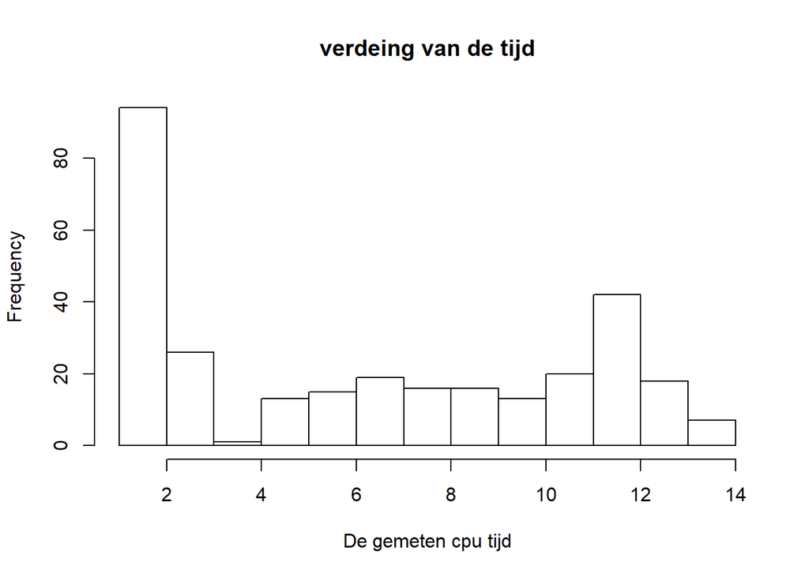

```r
hist(android_cpu$Tijd, main = "verdeing van de tijd", xlab = "De gemeten cpu tijd");
```

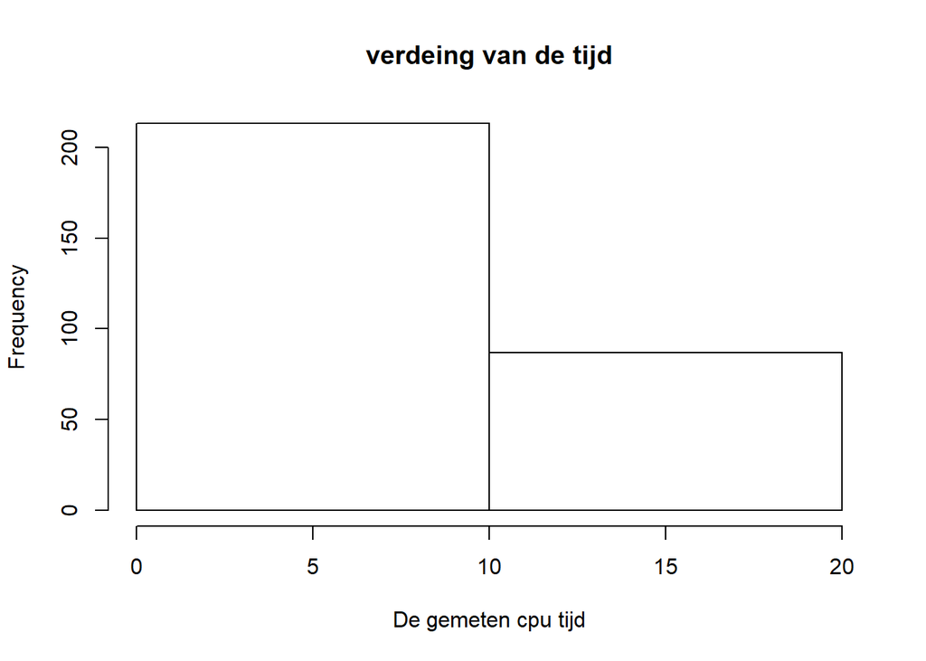

```r
#default "break" = 10
hist(android_cpu$Tijd, main = "verdeing van de tijd", xlab = "De gemeten cpu tijd", breaks = 1);
```

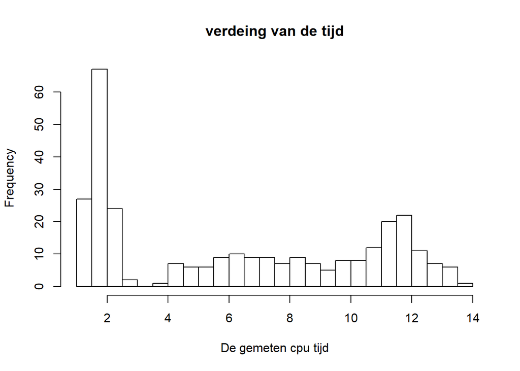

```r
hist(android_cpu$Tijd, main = "verdeing van de tijd", xlab = "De gemeten cpu tijd", breaks = 20);
```

Wat concludeer je als je bovenstaande grafieka genereert? Is dit een zinnig resultaat? Wat gebeurt er als je de variabele breaks verhoogt?

## oplossing

### nuttig?

Het is niet zo nuttig om te weten hoe vaak een bepaalde uitkomst voorkomt Het lijkt mij interessanter om te zien wat de gemiddelde cpu tijd per persistence unit is

### breaks

de “breaks” variabele steltin in hoeveel categoriëren de dataset gesplitst wordt. default is deze waarde 10.

**oplossing chamilo:** De voorkomens van per cpu tijd zijn zichtbaar. Je kan afleiden dat er 1 groot interval is en deze dus de mean kan beïnvloeden. De categorieën zijn echter niet zichtbaar dus er is niet veel nut aan de grafiek Op de x as zijn de intervallen vergroot.

# Oefening 3.12.

*(oefening zelf gemaakt, geen oplossing)*

## Opgave

De boxplot wordt standaard verticaal getekend

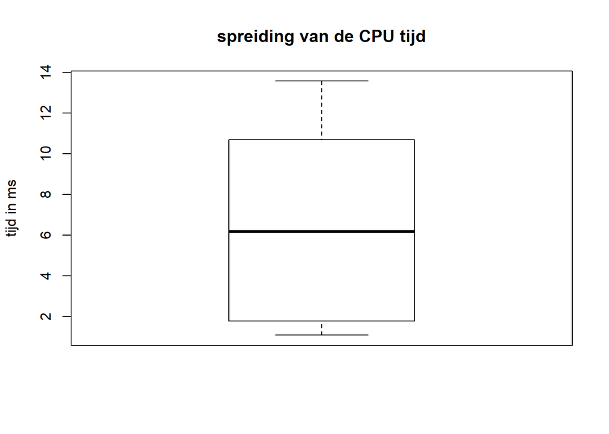

```r
boxplot(android_cpu$Tijd, main="spreiding van de CPU tijd", ylab ="tijd in ms")
```

## Oplossing

# Oefening 3.13.

*(oefening zelf gemaakt, geen oplossing)*

## Opgave

Als je goed geantwoord hebt op de volgende vragen merk je natuurlijk dat het weinig zin heeft de volledige dataset te analyseren, aangezien de dataset verdeeld is over verschillende categorieën. We willen dus wel deze statistieken weten, maar per categorie. We kunnen dus een boxplot maken voor elke categorie

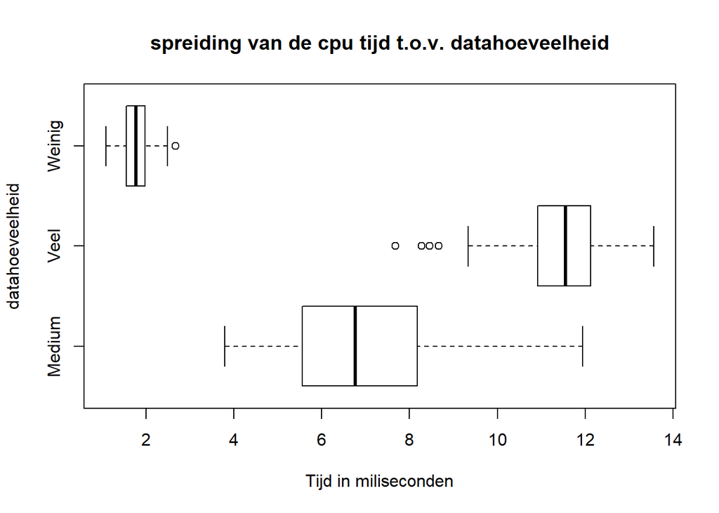

```r
boxplot(android_cpu$Tijd~android_cpu$Datahoeveelheid, main = "spreiding van de cpu tijd t.o.v. datahoeveelheid", xlab = "Tijd in miliseconden",ylab = "datahoeveelheid", horizontal = TRUE)
```

Interpreteer de resultaten die je behaalt uit deze grafiek. Zijn deze al wat zinniger?

## Oplossing

Nee niet echt, Het is logisch dat bij een grote datahoeveelheid de tijd in miliseconden groter zal zijn

Het is wel opvallend dat de spreiding bij medium grote datahoeveelheden heel groot is. We weten natuurlijk niet wat de intervallen zijn die “medium” definieeren. Als dit interval breder is dan bij “klein” en “groot” is deze observatie logisch

**oplossing chamilo:**

Er is een duidelijker overzicht met uitschieters van de datahoeveelheid. De volledige data is echter nog niet weergegeven.

# oefening 3.14

*(oefening zelf gemaakt, geen oplossing)*

## opgave

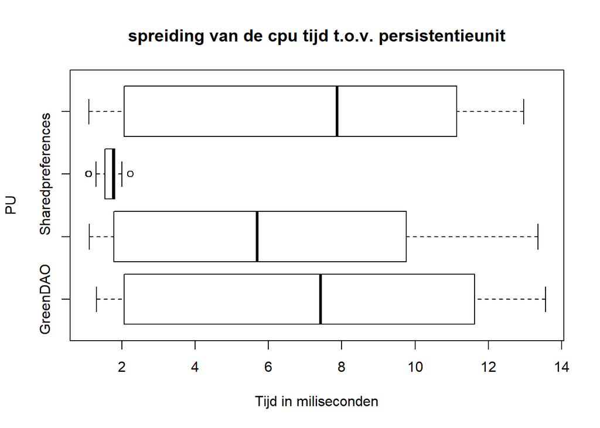

```r
boxplot(android_cpu$Tijd~android_cpu$PersistentieType, main = "spreiding van de cpu tijd t.o.v. persistentieunit", xlab = "Tijd in miliseconden",ylab = "PU", horizontal = TRUE)
```

Zijn deze resultaten zinniger?

## oplossing

Nee niet echt

# oefening 15

We moeten de data dus onderverdelen in categorieën namelijk onder PersistentieType en Datahoeveelheid. We gaan hiervoor de functie which1 gebruiken en kijken hoe de verschillende datahoeveelheden verschillen per datahoeveelheidcategorie.

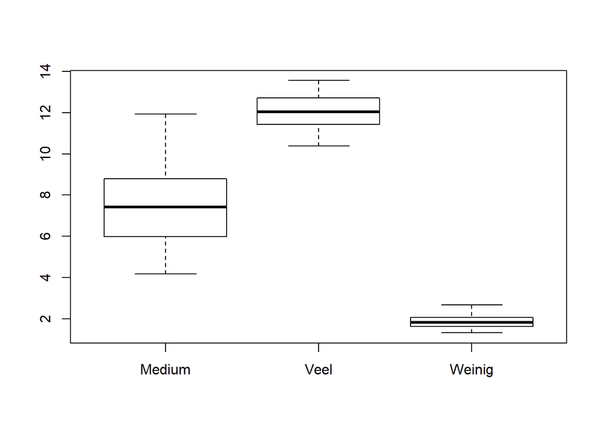

```r
greenDOA <- android_cpu[which(android_cpu$PersistentieType=='GreenDAO'),];
boxplot(greenDOA$Tijd~greenDOA$Datahoeveelheid)
```

wat conludeer je

## oplossing

dat deze persistence unit recht evenredig werkt in functie van de datahoeveelheid. (zoals verwahct)

Bij medium is de spreiding wel opvallend hoog.

# voorbeelden

blz 38

## bewerkingen op een vector

```r
a <- c(1,2,3,4)
a
```

```
## [1] 1 2 3 4
```

```r
a <- a + 5
a
```

```
## [1] 6 7 8 9
```

```r
a <- a * 3
a
```

```
## [1] 18 21 24 27
```

```r
b <- a -15
b
```

```
## [1]  3  6  9 12
```

```r
# wortel
sqrt(a)
```

```
## [1] 4.242641 4.582576 4.898979 5.196152
```

## analyses op 1 variabele

```r
#inlezen csv
computers <- read.csv("C:/Users/tijsm/Google Drive/HoGent 2018-2019/2e semester/Onderzoekstechnieken/files/onderzoekstechnieken-cursus/cursus/data/computers.csv")
# vermijden dat er steeds computers$ moet getypt worden
attach(computers)
```

```r
#gemiddelde
mean(price)
```

```
## [1] 2219.577
```

```r
#mediaan
median(price)
```

```
## [1] 2144
```

```r
#kwartielen
quantile(price)
```

```
##   0%  25%  50%  75% 100%
##  949 1794 2144 2595 5399
```

```r
#minimum
min(price)
```

```
## [1] 949
```

```r
#maximum
max(price)
```

```
## [1] 5399
```

```r
#variantie
var(price)
```

```
## [1] 337333.2
```

```r
#standaardafwijking
sd(price)
```

```
## [1] 580.804
```

```r
## alles
summary(computers)
```

```
##      price          speed              hd              ram
##  Min.   : 949   Min.   : 25.00   Min.   :  80.0   Min.   : 2.000
##  1st Qu.:1794   1st Qu.: 33.00   1st Qu.: 214.0   1st Qu.: 4.000
##  Median :2144   Median : 50.00   Median : 340.0   Median : 8.000
##  Mean   :2220   Mean   : 52.01   Mean   : 416.6   Mean   : 8.287
##  3rd Qu.:2595   3rd Qu.: 66.00   3rd Qu.: 528.0   3rd Qu.: 8.000
##  Max.   :5399   Max.   :100.00   Max.   :2100.0   Max.   :32.000
##      screen        cd       multi      premium         ads
##  Min.   :14.00   no :3351   no :5386   no : 612   Min.   : 39.0
##  1st Qu.:14.00   yes:2908   yes: 873   yes:5647   1st Qu.:162.5
##  Median :14.00                                    Median :246.0
##  Mean   :14.61                                    Mean   :221.3
##  3rd Qu.:15.00                                    3rd Qu.:275.0
##  Max.   :17.00                                    Max.   :339.0
##      trend
##  Min.   : 1.00
##  1st Qu.:10.00
##  Median :16.00
##  Mean   :15.93
##  3rd Qu.:21.50
##  Max.   :35.00
```